# Phospho-dependent domain discovery from the array data

Bora Uyar

Fri Nov 3 14:38:21 2023

Import required libraries

```r
knitr::opts_chunk$set(echo = TRUE, message = F, warning = F, fig.height = 7, fig.width = 9)
suppressPackageStartupMessages(library(slimR))
suppressPackageStartupMessages(library(data.table))
suppressPackageStartupMessages(library(parallel))
suppressPackageStartupMessages(library(ggplot2))
suppressPackageStartupMessages(library(ggpubr))
suppressPackageStartupMessages(library(ComplexHeatmap))
suppressPackageStartupMessages(library(cowplot))

ggplot2::theme_set(ggpubr::theme_pubclean())
data.table::setDTthreads(12)

datadir <- params$datadir
outdir <- params$outdir

if(!dir.exists(datadir)) {stop(datadir, "doesn't exist")}
if(!dir.exists(outdir)) {stop(outdir, "doesn't exist")}

figureDir <- file.path(outdir, "figures")
if(!dir.exists(figureDir)) {dir.create(figureDir)}
```

# 1 Motivation

We’d like to find out if we can detect an enrichment of phospho-dependent binding domains in the array data.

# 2 Data preparation

Importing and processing peptide info:

```r
peptides <- data.table::fread(file.path(datadir,  'PeptideCandidates1.txt'))
peptides$type <- 'wt'
peptides[grepl('_', peptides$Name)]$type <- 'mut'
peptides[grepl('phos', peptides$Name),]$type <- 'phos'
# remove the leading lower-case 'p' in the phosphorylated form of the sequence
#peptides$Peptide <- gsub("p([STY])", paste0("_phos_", "\\1"), peptides$Peptide)
peptides$Peptide <- gsub("p([STY])", "\\1", peptides$Peptide)
# add leading and trailing "XXX" to the peptide sequence to avoid matching terminal motifs
peptides$Peptide <- paste0('XXX',peptides$Peptide,'XXX')
# assign experiment group ids to make it compatible with Expgroup ids in array data
peptides$Expgroup <- ceiling(peptides$ID/3)*3-2
```

Get uniprot accessions and corresponding gene names from the fasta file of human uniprot sequences

```r
message('Importing fasta sequences')
fasta <- Biostrings::readAAStringSet(file.path(datadir, 'uniprot.9606.Nov_1_2021.fasta'))
uniprot2geneName <- unique(data.table('uniprotAccession' = sub("^sp\\|(.+?)\\|.+$", "\\1", names(fasta)),
                                      'geneName' = sub("^.+ GN=(.+?) .+$", "\\1", names(fasta)),
                                      stringsAsFactors = FALSE))
# simplify fasta headers of fasta data
names(fasta) <- sub("^sp\\|(.+?)\\|.*", "\\1", names(fasta))
```

Get LFQ data, process protein ids, cleanup, assign uniprot ids, get mean LFQ value per interaction from replicates

```r
#import LFQ interaction results
lfqData <- fread(file.path(datadir, 'LFQinteractions.txt'))
# simplify uniprot accession/gene name fields => remove unreviewed ids and keep only one per row
cl <- parallel::makeCluster(10)
parallel::clusterExport(cl, varlist = c('lfqData', 'uniprot2geneName'))
s <- pbapply::pbsapply(cl = cl, strsplit(lfqData$Protein.IDs, ";"), function(x) {
  # pick first match
  intersect(x, uniprot2geneName$uniprotAccession)[1]
})
lfqData$uniprotAccession <- s
parallel::stopCluster(cl)

lfqData <- lfqData[!is.na(uniprotAccession)]

lfqData <- melt.data.table(lfqData, id.vars = 'uniprotAccession',
                measure.vars = grep('wt|mut|phos', colnames(lfqData), value = T))
lfqData$variable <- as.character(lfqData$variable)
lfqData$type <- sub("(wt|phos|mut).+", "\\1", lfqData$variable)
lfqData$Expgroup <- gsub("\\.[0-9]+$", "", gsub("(wt|phos|mut)", "", lfqData$variable))

# get mean LFQ value per interaction
lfqData <- lfqData[,mean(value, na.rm = T), by = c('uniprotAccession', 'type', 'Expgroup')][!is.na(V1)]

# normalize lfqData
x <- dcast(lfqData, Expgroup + type ~ uniprotAccession, value.var = 'V1')
M <- as.matrix(data.frame(x[,-c(1,2)], row.names = paste(x$Expgroup, x$type, sep = '_')))
M[is.na(M)] <- 15.7
lfqNorm <- t(scale(M))
```

Import PFAM annotations from Uniprot and download ELM-PFAM interaction information

```r
message("importing PFAM domains")
uniprot2pfam <- readRDS(file.path(datadir, 'uniprot2pfam.RDS'))
uniprot2pfam <- uniprot2pfam[uniprot2pfam$seqnames %in% unique(lfqData$uniprotAccession),]
uniprot2pfam <- unique(subset(uniprot2pfam, select = c('seqnames', 'pfam_acc', 'pfam_name', 'clan')))
colnames(uniprot2pfam) <- c('uniprotAccession', 'PFAM', 'NAME', 'CLAN')
message("importing ELM -> PFAM associations")
# download a table of ELM classes and their cognate PFAM domains
elm2pfam <- readRDS(file.path(datadir, 'elm2pfam.RDS'))

# simplify uniprot2pfam table:
# remove proteins that don't exist in the screen
uniprot2pfam <- uniprot2pfam[uniprotAccession %in% lfqData$uniprotAccession]
```

Get list of known phospho-dependent slim-domain pairs

```r
elms <- readRDS(file.path(datadir, 'elm_classes.RDS'))
pat <- "(\\(\\[[ST]+\\]\\)|\\([YTS]\\))"
phos_elms <- names(grep(pat, unlist(elms[grep('MOD|TRG|CLV', names(elms), invert = T)]), value = T))
phos_domains <- unique(elm2pfam[ELM_identifier %in% phos_elms]$Interaction_Domain_Name)
```

```r
# create feature matrix (features are protein domains and values are 1/0 if the protein has the corresponding domain)
domains <- unique(uniprot2pfam[uniprotAccession %in% rownames(lfqNorm)]$NAME)
M <- matrix(rep(0, nrow(lfqNorm) * length(domains)), nrow = nrow(lfqNorm), ncol = length(domains),
            dimnames = list(rownames(lfqNorm), domains))
# for each protein, if the protein has the domain, switch value to 1
dt <- droplevels(uniprot2pfam[uniprotAccession %in% rownames(lfqNorm)][!is.na(uniprotAccession)])
dtl <- lapply(split(dt, dt$uniprotAccession), function(x) unique(x$NAME))

counts <- do.call(rbind, lapply(rownames(M), function(p) {
  x <- M[p,]
  if(p %in% names(dtl)) {
      x[dtl[[p]]] <- 1
  }
  return(x)
}))
rownames(counts) <- rownames(M)
phos_domains <- intersect(colnames(counts), phos_domains)
```

Import Array Data (LFQ + SILAC dataset)

```r
arrayDataFile <- file.path(datadir, 'SILACLFQ_extended_loose_p001FD_1.txt')
arrayData <- data.table::fread(arrayDataFile)
# simplify uniprot accession/gene name fields => remove unreviewed ids and keep only one per row
cl <- parallel::makeCluster(10)
parallel::clusterExport(cl, varlist = c('arrayData', 'uniprot2geneName'))
s <- pbapply::pbsapply(cl = cl, strsplit(arrayData$Majority.protein.IDs, ";"), function(x) {
  # pick first match
  intersect(x, uniprot2geneName$uniprotAccession)[1]
})
arrayData$uniprotAccession <- s
parallel::stopCluster(cl)

# modify arrayData to have one line per protein & peptide in the screen
arrayData$SILACGroup <- gsub("[0-9]+$", "", arrayData$SILACGroup)
colnames(arrayData) <- gsub("_", ".", gsub("LFQsignificant", "lfq_", colnames(arrayData)))

arrayData <- data.table::dcast.data.table(arrayData[!is.na(uniprotAccession)],
                 Expgroup + uniprotAccession + lfq.Wt.loose + lfq.Phos.loose + lfq.Mut.loose ~ SILACGroup,
                 value.var = 'Median.SILAC.ratio')
# keep interactions that are not NA for any silac values
to_keep <- apply(arrayData[,c('phos_mut', 'wt_mut', 'wt_phos')], 1, function(x) sum(!is.na(x)) == 3)
arrayData <- arrayData[to_keep]
```

# 3 Domain Enrichment Analysis

Find proteins that are LFQ+ for phosphorylated form of the peptide. For each domain, count the number of proteins containing the domain among this population and compare to the background distribution.

```r
t <- colSums(counts[,phos_domains])
p1 <- ggplot(data.table('domain' = names(t), 'count' = as.numeric(t)),
        aes(x = reorder(domain, -count), y = count)) + geom_bar(aes(fill = log(count)),
                                                                stat = 'identity', show.legend = F) +
  labs(x = 'Phospho-domain', y = 'Number of proteins in the screen') + geom_hline(yintercept = 5)
```

```r
candidates <- unique(arrayData[lfq.Phos.loose == '+']$uniprotAccession)
# only considering domains that are found in at least 5 proteins in the screen
stats <- do.call(rbind, pbapply::pblapply(names(which(colSums(counts) > 5)), function(d) {
  # find the number of proteins in the screen containing the domain
  bg_count <- sum(counts[,d]) #number of proteins in the screen containing the domain
  phos_count <- sum(counts[candidates, d]) # number of proteins that are LFQ+ for phos peptide containing the domain
  exp_count <- length(candidates) * bg_count/nrow(counts) # number of proteins expected to observe among LFQ+ phos
  t <- binom.test(x = phos_count, n = length(candidates), p = bg_count / nrow(counts), alternative = 'greater') # p.value for hypergeometric test
  data.table('domain' = d, 'phos' = phos_count, 'expected' = exp_count, 'pval' = t$p.value)
}))[order(pval)]


p2 <- ggplot(stats[pval < 0.05],
        aes(x = reorder(domain, pval), y = -log10(pval))) +
  geom_bar(aes(fill = domain %in% phos_domains),
               stat = 'identity', show.legend = F) + coord_flip() +
  labs(x = 'Domain', y = '-log10(pval) (binomial test)') +
  scale_fill_brewer(type = 'qual', palette = 3) +
  geom_hline(yintercept = -log10(0.05))
```

# 4 using silac ratios to find candidates

With this approach, we rank the domains by the average silac ratios of lfq phos + interaction partners across peptides

```r
# phos vs mut
phos_mut_dt <- arrayData[lfq.Phos.loose == '+', mean(phos_mut), by = 'uniprotAccession']

# for each domain find proteins that contain the domain, get the mean silac ratios
stats_silac <- do.call(rbind, pbapply::pblapply(colnames(counts), function(d) {
  selected <- names(which(counts[,d] == 1))
  data.table::data.table('domain' = d, 'mean_phos_mut' = mean(phos_mut_dt[uniprotAccession %in% selected]$V1, na.rm = T))
}))
```

Top-ranking domains in terms of the mean SILAC ratios phos/mut across peptides

```r
p3 <- ggplot(stats_silac[order(mean_phos_mut, decreasing = T)][1:30],
             aes(x = reorder(domain, mean_phos_mut), y = mean_phos_mut)) +
  geom_bar(stat = 'identity', aes(fill = domain %in% phos_domains), show.legend = T) + coord_flip() +
  labs(x = 'Domain', y = 'Mean SILAC ratio (phos/mut) across peptides') +
  scale_fill_brewer(type = 'qual', palette = 3) +
  theme(legend.position = 'bottom')
```

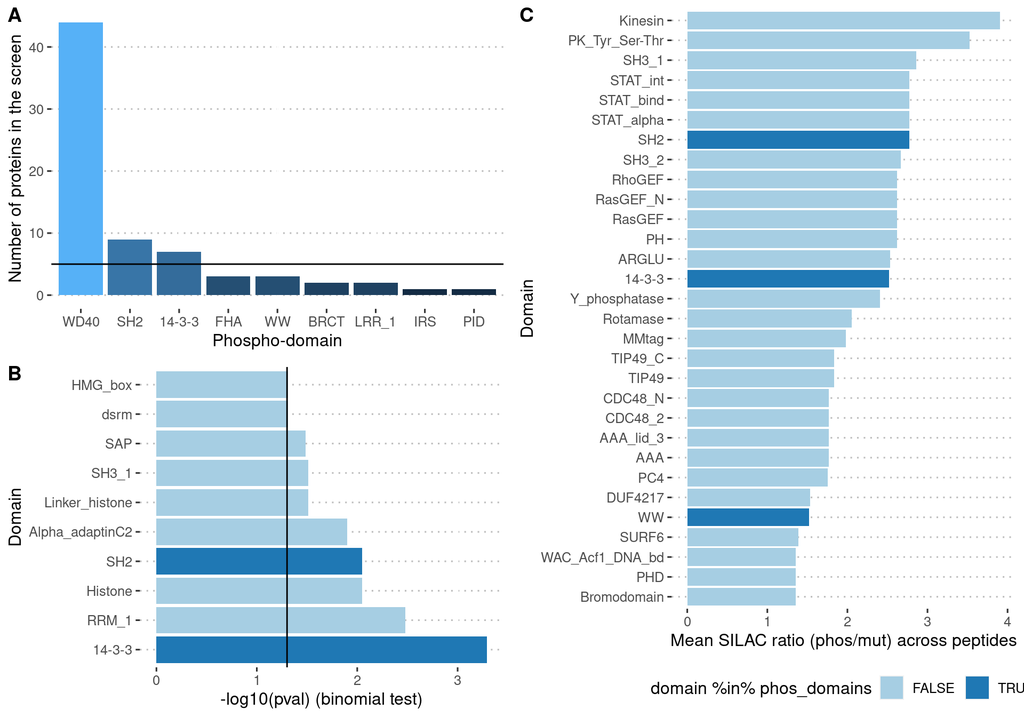

```r
cowplot::plot_grid(
  cowplot::plot_grid(p1, p2, ncol = 1, labels = c('A', 'B')),
  p3, ncol = 2, labels = c('', 'C')
)
```

```r
ggsave(filename = file.path(figureDir, 'phospho_domain_analysis.pdf'),
       width = 12, height = 8)
```

- Only few SLiM-binding phospho-dependent domains are found in at least 5 proteins in the whole screen. (Panel A)
- Among these 14-3-3 and SH2 domains are enriched (compared to the domain distribution of the full set of proteins detected in the screen) for interaction partners which are LFQ+ for the phosphorylated form of the peptides. (Panel B)
- If we look into the average phos/mut SILAC ratios for the proteins which are LFQ+ for phoshorylated form of the peptides, we can see the 14-3-3, SH2, and WW make it among the top 30 domains. Other domains are potentially those that are likely to co-occur with phospho-dependent domains. But, this could serve as a list of potential phospho-recognition domains based on this screen. (Panel C)

# 5 Co-occurrence stats of domains in the screen

We’d like to see which non-phospho-dependent domains co-occur the most with phospho-dependent domains.

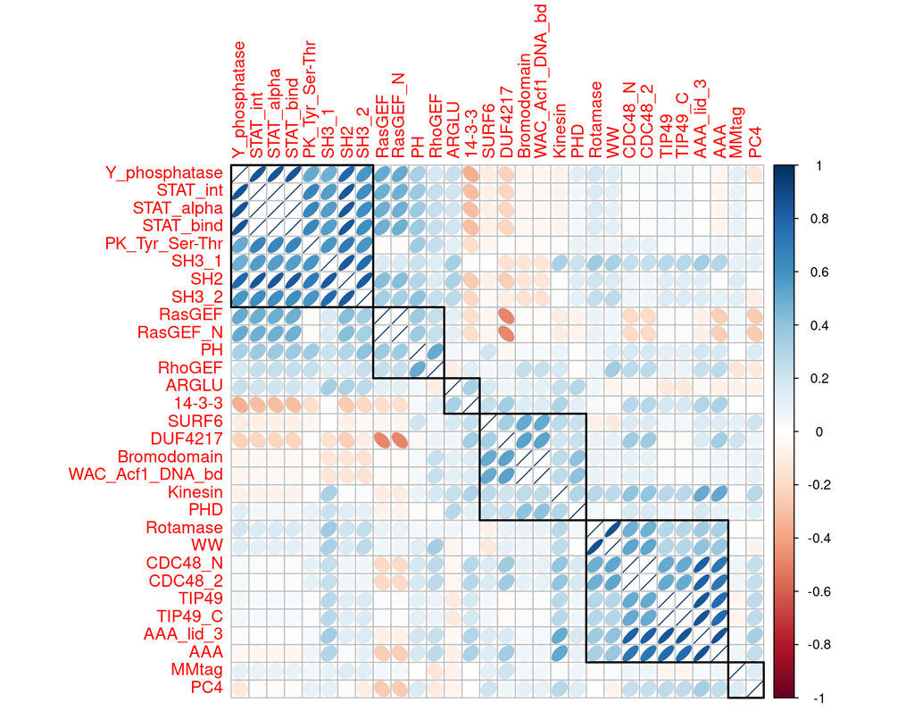

```r
# for each peptide and for each domain, count number of proteins that contain the domain
dt <- cbind(lfqData, counts[lfqData$uniprotAccession,])
mdt <- data.table::melt.data.table(dt, measure.vars = colnames(counts))
peptides_domains <- mdt[,sum(value),by = c('type', 'variable', 'Expgroup')]
# remove domains that are not found at all
m <- dcast.data.table(peptides_domains, type + Expgroup ~ variable, value.var = 'V1')
m <- as.matrix(data.frame(m[,-c(1:2)], row.names = paste0(m$Expgroup, "_", m$type), check.names = F))

# compute correlation of "SH2" vs all other domains
# remove uninformative domains
m <- m[,names(which(apply(m, 2, sd) > 0))]
s <- stats_silac[order(mean_phos_mut, decreasing = T)][1:30]$domain
corrplot::corrplot(cor(m[,s]), method = 'ellipse',
                   order = 'hclust', addrect = 6)
```

```r
p <- recordPlot()
pdf(file = file.path(figureDir, "domain_correlation.pdf"), width = 9, height = 9)
replayPlot(p)
dev.off()
```